# DS 202: Sample Exam

## Question #3 : On the court

The variables `converted_x` and `converted_y` give the location of the acting player on the court. Check with the variable `event_type` to see, for which types of play we have geographic information.

For game number `21700003` plot the geographic location of each play on the court, colour by team and incorporate visually the play’s outcome (variable `result`). Describe the result.

```r
pbp %>% group_by(event_type, is.na(converted_x), is.na(converted_y)) %>% tally()
```

```
## # A tibble: 13 x 4
## # Groups:   event_type, is.na(converted_x) [?]
##    event_type      `is.na(converted_x)` `is.na(converted_y)`     n
##    <fct>           <lgl>                <lgl>                <int>
##  1 end of period   TRUE                 TRUE                    20
##  2 foul            TRUE                 TRUE                   221
##  3 free throw      TRUE                 TRUE                   241
##  4 jump ball       TRUE                 TRUE                     5
##  5 miss            FALSE                FALSE                  486
##  6 rebound         TRUE                 TRUE                   532
##  7 shot            FALSE                FALSE                  419
##  8 start of period TRUE                 TRUE                    20
##  9 sub             TRUE                 TRUE                   221
## 10 timeout         TRUE                 TRUE                    55
## 11 turnover        TRUE                 TRUE                   147
## 12 unknown         TRUE                 TRUE                     7
## 13 violation       TRUE                 TRUE                    12
```

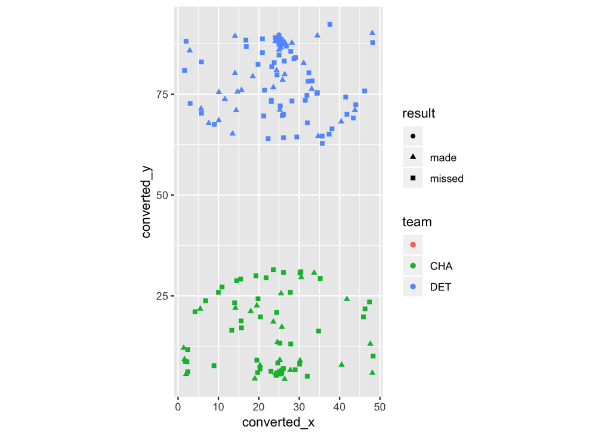

```r
# shots and mises have geographic information

pbp %>% filter(game_id==21700003) %>%
  ggplot(aes(x = converted_x, y = converted_y, colour=team, shape=result)) +
  geom_point() + coord_equal()
```

```r
# We see a clear pattern in the shots made and attempted. There are two tight clusters of shots attempted at the baskets, which spread out as distance increases. At the 3 point lines we can see another set of attempted shots.
```

## Question #4: Distance hurts?

Is there any evidence that shots closer to the basket are successful more often? For that, - introduce a new variable `d` into the data that captures the distance of a player from the basket (basket is in [0,0] for variables `original_x` and `original_y`). - draw side-by-side boxplots of distance by result and team (using ggplot2). Interpret.

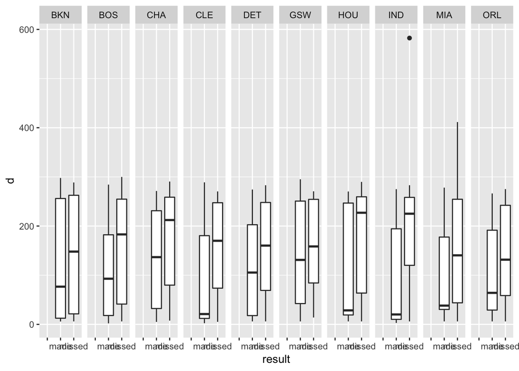

```r
pbp$d <- with(pbp, sqrt(original_x^2+original_y^2))
pbp %>% filter(team!="") %>%
  ggplot(aes(x = result, y = d)) +
  facet_grid(.~team) + geom_boxplot()
```

```r
# there is a clear difference in the distance associated with shots made and shots missed. Distance does hurt. Shots that were made tend to be closer to the basket.
```

## Question #5: Timeline

The variable `elapsed` is recorded in hour-minute-second format. Convert the information into seconds (hint: you could introduce helper variables for the conversion). The `elapsed` time variable starts over in each period (a period has 12 mins). Introduce a new variable called `time_played` that keeps track of the time (in seconds) from the beginning of a game to the end.

Plot the timeline (`time_played`) of events (`event_type`) for game with the id `21700002` in a scatterplot. Colour by team. Comment on the result.

```r
library(lubridate)
```

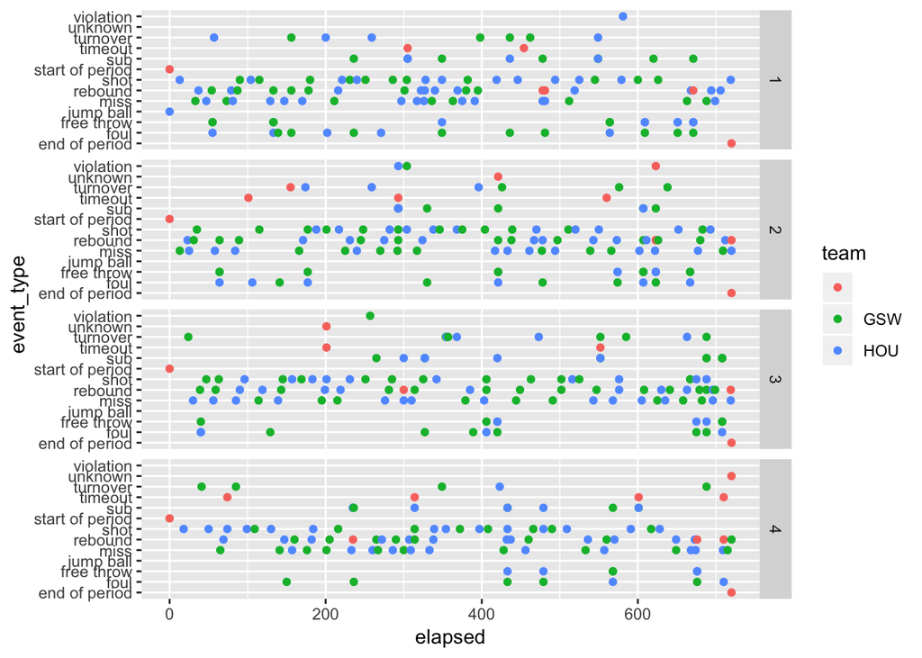

```r
pbp <- pbp %>% separate(elapsed, into=c("hour", "minute", "second"), sep=":") %>%
  mutate(
  elapsed = as.numeric(minute)*60+as.numeric(second),
  time_played = elapsed + 12*60*(period-1)
)
pbp %>%
  filter(game_id=="21700002") %>%
  ggplot(aes(x = elapsed, y = event_type,  colour=team)) +
  geom_point() +
  facet_grid(period~.)
```

```r
# there should be clear changes  between home and away team showing teams' plays, but on this scale this is hard to see.
```

## Question #6: Who is playing?

Variables `h1` through `h5` and `a1` through `a5` are the five players of the home team and the away team on the field at that moment in positions 1 through 5. Reshape the data set to combine all player variables. Extract position numbers. For each game identify how many players were playing in each position.

Draw side-by-side boxplots of the number of players by position. Comment.

```r
players <- pbp %>% gather(teamposition, player, a1:h5) %>%
  mutate(
    position = parse_number(teamposition)
  ) %>%
  group_by(position, game_id) %>%
  summarise(num_players = length(unique(player)))
```

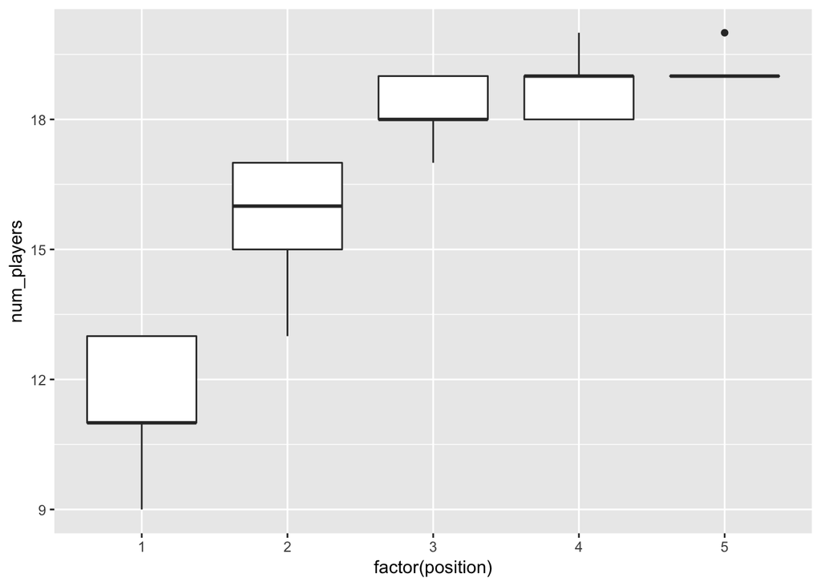

```r
players %>% ggplot(aes(x = factor(position), y=num_players))  +
  geom_boxplot()
```

```r
# quite a few players are exchanged in each position throughout a game (probably about half are from each of the teams - ideally we should distinguish between home and away team)
# position #1 has the fewest players,
# followed by position #2.
# the other positions see more changes.
```